# HCA Jamboree : How Many Cells Task

The purpose of this task is to help answer the question that we are always asked (or ask ourselves!) : How many cells do I need to sequence for my experiment?

We know that the ability to separate cells into clusters is dependent on many factors, including:

- Total cell number in the experiment
- Frequency of the cluster
- Sequencing depth
- Transcriptional ‘distinctness’ of the clusters.

Your task is to build a model to predict the separability of any two pairs of clusters, for any dataset. You can see exact specifications for inputs and outputs in the task README.

In this vignette, we analyze a dataset of ~9,000 pancreatic human islet cells, to demonstrate the relationship between separability and cell size, for different pairs of clusters. We suggest that you run similar analyses on all the datasets we provide, and leverage these results to build your model.

Setup and load in data form loom file

```r
library(Seurat)
library(rhdf5)
library(RANN)
library(tidyr)
library(dplyr)
```

```r
loom_file <- "/home/jovyan/data/tasks/how_many_cells/human_pancreas.loom"

# we can read this using loomR, but since that might not be installed, we'll read using HDF5
data <- h5read(loom_file,name = "/")
data_matrix <- t(data$matrix)
dimnames(data_matrix) <- list(data$row_attrs$gene_names, data$col_attrs$cell_names)
cluster_ids <- data$col_attrs$cluster; names(cluster_ids) <- colnames(data_matrix)
rm(data)
data_matrix <- Matrix(data_matrix,sparse=T)

#view a few lines of the UMI matrix
head(data_matrix[20:25,1:3])
```

```
## 6 x 3 sparse Matrix of class "dgCMatrix"
##       human1_lib1.final_cell_0001 human1_lib1.final_cell_0002
## AAMP                            .                           1
## AANAT                           .                           .
## AAR2                            .                           2
## AARD                            .                           .
## AARS                            .                           2
## AARS2                           .                           2
##       human1_lib1.final_cell_0003
## AAMP                            .
## AANAT                           .
## AAR2                            .
## AARD                            .
## AARS                            .
## AARS2                           .
```

```r
print(dim(data_matrix))
```

```
## [1] 20125  8569
```

```r
data.frame(table(cluster_ids))
```

| cluster_ids | Freq |
| --- | --- |
| acinar | 958 |
| activated_stellate | 284 |
| alpha | 2326 |
| beta | 2525 |
| delta | 601 |
| ductal | 1077 |
| endothelial | 252 |
| epsilon | 18 |
| gamma | 255 |
| macrophage | 55 |

[output cut: 4 more lines]

[output not shown]

We demonstrate the following steps using Seurat, but of course, you can use any analysis pipeline starting from the UMI matrix

```r
object <- CreateSeuratObject(raw.data = data_matrix)
object <- NormalizeData(object,display.progress = F,scale.factor = 1e4,normalization.method = "LogNormalize")
```

Now we define functions to define separability between any two clusters

- The ComputeSeparabiltiy function itself takes cells from two pre-annotated clusters, and an input data matrix. It calculates KNN (k=20) for these cells, and outputs the average fraction of a cell’s neightbors that are in the same cluster. Ranges from 0..1
- You are welcome to recode ComputeSeparability in another langage, but please compute the same metric for evaluation purposes
- ProcessData performs feature selection, and returns a matrix that will be input to the KNN above. Here, we perform PCA on the 1,000 genes with highest mean/variance ratios, but you can use any unsupervised method you like

```r
ProcessData <- function(object) {
  object <- FindVariableGenes(object, do.plot = FALSE, display.progress = FALSE)
  object@var.genes <- rownames(head(object@hvg.info, 1000))
  object <- ScaleData(object, genes.use = object@var.genes,
                      display.progress = FALSE, check.for.norm = FALSE)
  object <- RunPCA(object, pcs.compute = 30, do.print = FALSE)
  return(GetCellEmbeddings(object, reduction.type = "pca", dims.use = 1:30))
}

ComputeSeparability <- function(input.data, cells.1, cells.2, k = 20) {
  if (length(cells.1) < 3) {
    #warning("Fewer than 3 cells in the first group (cells.1)")
    return(NA)
  }
  if (length(cells.2) < 3) {
    #warning("Fewer than 3 cells in the second group (cells.2)")
    return(NA)
  }
  k <- min(c(k, length(cells.1), length(cells.2)))
  tnn <- nn2(data = input.data[c(cells.1, cells.2), ], k = k + 1)
  idx <- tnn$nn.idx[, -1]
  rownames(idx) <- c(cells.1, cells.2)
  correct_neighbors_c1 <- sapply(cells.1, function(x)
    {
      length(which(rownames(idx)[idx[x,]] %in% cells.1))
    }
  )
  correct_neighbors_c2 <- sapply(cells.2, function(x)
    {
      length(which(rownames(idx)[idx[x,]] %in% cells.2))
    }
  )
  return(mean(c(correct_neighbors_c1, correct_neighbors_c2)) / k)
}
```

```r
results=list()
ncell_use=c(seq(250,5000,250),seq(5500,8500,500))
cluster_separabilities <- tibble(ncell = numeric(), clusters = character(), separability = double())

for(n_cell in 1:length(ncell_use)) {
  #Downsample Seurat object
  downsample_cells <- ncell_use[n_cell]
  subsample <- SubsetData(object,cells.use = sample(object@cell.names,size = downsample_cells))

  #Run ProcessData
  data_for_knn = ProcessData(subsample)

  #Now, compute all pairs of separabilities for all clusters
  clusters_compute <- unique(cluster_ids)
  subsample_cells <- subsample@cell.names

  for(i in 1:length(clusters_compute)) {
    for(j in 1:i) {
      if (j<i) {
        cells_1 <- intersect(subsample_cells,names(cluster_ids[which(cluster_ids==clusters_compute[i])]))
        cells_2 <- intersect(subsample_cells,names(cluster_ids[which(cluster_ids==clusters_compute[j])]))
        cluster_sep <- ComputeSeparability(data_for_knn,cells_1, cells_2, k = 20)
        cluster_comparison <- paste(clusters_compute[i],clusters_compute[j],sep=":")
        row_n <- nrow(cluster_separabilities)+1
        cluster_separabilities[row_n,"ncell"] <- downsample_cells; cluster_separabilities[row_n,"separability"] <- cluster_sep
        cluster_separabilities[row_n,"clusters"] <- paste(clusters_compute[i],clusters_compute[j],sep=":")
      }
    }
  }
  if (downsample_cells%%1000 == 0) print(downsample_cells)
}
```

```
## [1] 1000
## [1] 2000
## [1] 3000
## [1] 4000
## [1] 5000
## [1] 6000
## [1] 7000
## [1] 8000
```

```r
print(head(cluster_separabilities))
```

```
## # A tibble: 6 x 3
##   ncell clusters                  separability
##   <dbl> <chr>                            <dbl>
## 1  250. beta:acinar                      0.978
## 2  250. delta:acinar                     0.971
## 3  250. delta:beta                       0.947
## 4  250. activated_stellate:acinar        0.900
## 5  250. activated_stellate:beta          0.963
## 6  250. activated_stellate:delta         0.804
```

Visualize a few ‘separability’ curves, where the x-axis is # of cells, and y-axis is separability

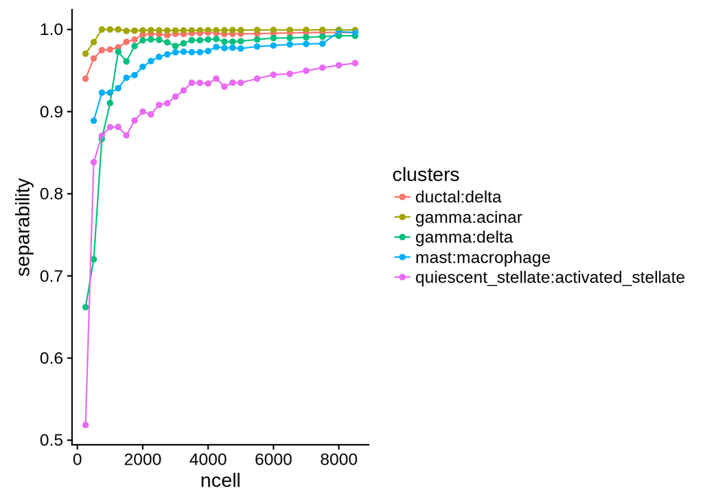

```r
all_data <- filter(cluster_separabilities, !is.na(separability))
#plot separability as a function of n for a few examples
test <- filter(all_data, clusters %in% c("gamma:delta","gamma:acinar","quiescent_stellate:activated_stellate","ductal:delta","mast:macrophage"))
ggplot(test,aes(x=ncell, y=separability, col=clusters))+geom_point() + geom_line()
```

Now add information about the # of DE genes and frequency

- Note that we are very simply defining DE genes as # of genes with an, on average, >2-fold change
- Also, we plot a few bulk transcriptomes against each other for visualization (same cluster comparisons shown above)

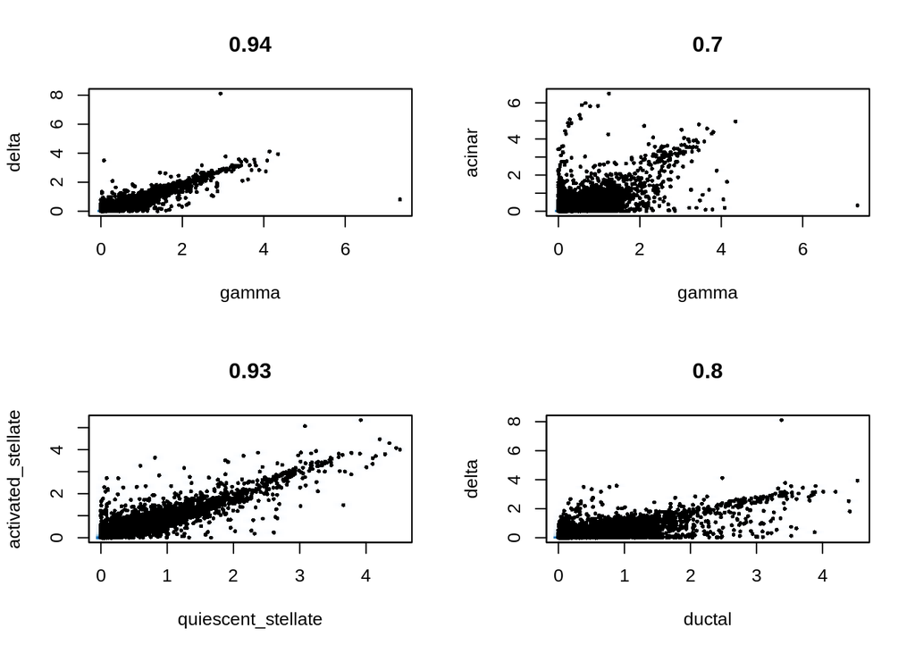

```r
object <- SetIdent(object, names(cluster_ids),cluster_ids)
avg_cluster <- AverageExpression(object,return.seurat = T,show.progress = F)
par(mfrow=c(2,2))
CellPlot(avg_cluster,"gamma","delta")
CellPlot(avg_cluster,"gamma","acinar")
CellPlot(avg_cluster,"quiescent_stellate","activated_stellate")
CellPlot(avg_cluster,"ductal","delta")
```

```r
NumDEGenes <- function(avg_cluster, cluster_comparison) {
  cluster_1 <- ExtractField(cluster_comparison,1,":")
  cluster_2 <- ExtractField(cluster_comparison,2,":")
  return(length(which(abs(avg_cluster@data[,cluster_1]-avg_cluster@data[,cluster_2])>log(2))))
}

num_de_genes <- sapply(1:nrow(all_data),function(x) NumDEGenes(avg_cluster, cluster_comparison = as.character(all_data$clusters[x])))
all_data$num_de_genes <- (num_de_genes)
all_data$frequency_cluster1 <- sapply(1:nrow(all_data),function(x) length(which(cluster_ids==ExtractField(as.character(all_data$clusters[x]),1,":"))) / length(cluster_ids))
all_data$frequency_cluster2 <- sapply(1:nrow(all_data),function(x) length(which(cluster_ids==ExtractField(as.character(all_data$clusters[x]),2,":"))) / length(cluster_ids))

print(head(all_data))
```

```
## # A tibble: 6 x 6
##   ncell clusters               separability num_de_genes frequency_cluste…
##   <dbl> <chr>                         <dbl>        <int>             <dbl>
## 1  250. beta:acinar                   0.978          509            0.295
## 2  250. delta:acinar                  0.971          446            0.0701
## 3  250. delta:beta                    0.947           88            0.0701
## 4  250. activated_stellate:ac…        0.900          605            0.0331
## 5  250. activated_stellate:be…        0.963          625            0.0331
## 6  250. activated_stellate:de…        0.804          615            0.0331
## # ... with 1 more variable: frequency_cluster2 <dbl>
```

Now build an overly simple regression model to try and predict cluster separation based on: * # of cells * Frequency of both clusters * Number of DE genes

```r
final_model <- lm(separability ~ num_de_genes + frequency_cluster1 + frequency_cluster2 + ncell,data = all_data)
coef(final_model)
```

```
##        (Intercept)       num_de_genes frequency_cluster1
##       9.473845e-01       5.258226e-06       5.237741e-02
## frequency_cluster2              ncell
##       9.441674e-02       4.674249e-06
```

```r
drop1(final_model)
```

|  | Df | Sum of Sq | RSS | AIC |
| --- | --- | --- | --- | --- |
|  | NA | NA | 1.654167 | -14420.25 |
| num_de_genes | 1 | 0.003678947 | 1.657846 | -14417.74 |
| frequency_cluster1 | 1 | 0.026350682 | 1.680517 | -14390.18 |
| frequency_cluster2 | 1 | 0.171065612 | 1.825232 | -14222.58 |
| ncell | 1 | 0.225737451 | 1.879904 | -14162.69 |

[output not shown]

- Note that a lm is probably a bad choice here, obvious non-linear effects in the data

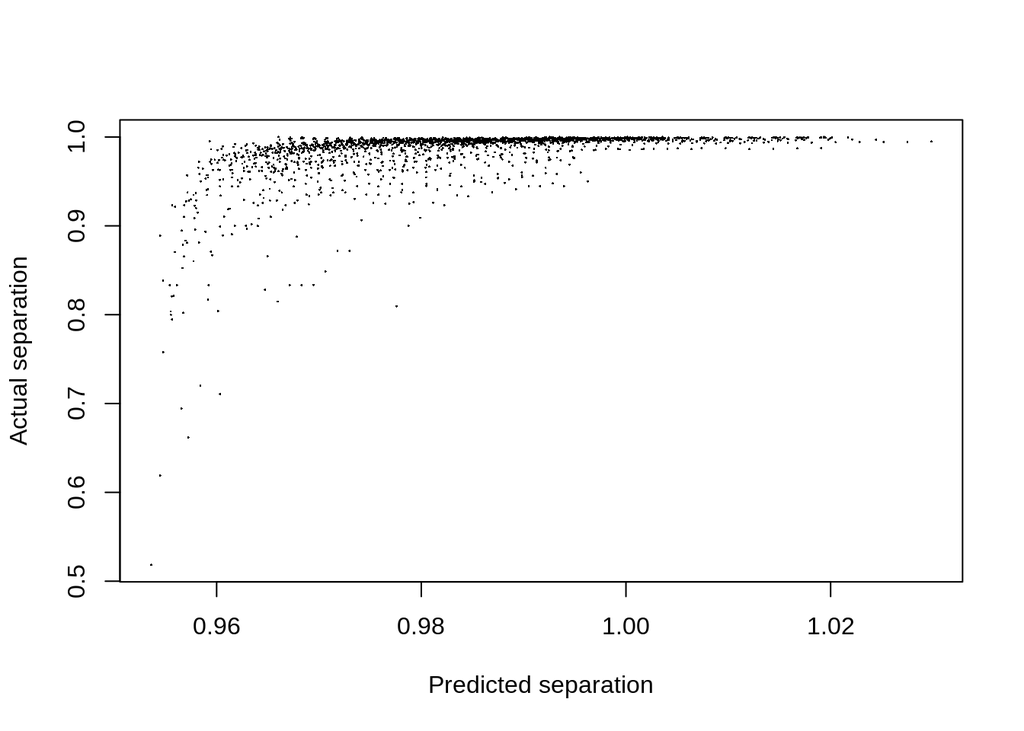

```r
plot(final_model$fitted.values,all_data$separability, xlab="Predicted separation", ylab="Actual separation",pch=16,cex=0.2)
```